# Week 5 - Teacher

Andrea Staten

9/21/2025

## Step 1

Load the tidyverse and janitor packages.

```r
library(tidyverse)
library(janitor)
```

## Step 2

Read the tidykids and NAEP data frames to your environment.

```r
tidykids <- read.csv("tidykids.csv")
naep <- read.csv("naep-data.csv")
```

## Step 3

Familiarize yourself with the two data frames using functions we’ve used before to do so.

```r
glimpse(naep)
```

```
## Rows: 51
## Columns: 4
## $ Jurisdiction             <chr> "Wyoming", "Massachusetts", "Nebraska", "Flor…
## $ Average.Score..0...500.  <int> 243, 242, 242, 241, 240, 240, 240, 240, 239, …
## $ At.or.Above.Basic..      <int> 84, 79, 80, 81, 79, 81, 80, 78, 80, 77, 78, 7…
## $ At.or.Above.Proficient.. <int> 44, 43, 43, 41, 43, 40, 40, 42, 40, 39, 40, 4…
```

```r
glimpse(tidykids)
```

```
## Rows: 1,150
## Columns: 6
## $ state            <chr> "Alabama", "Alaska", "Arizona", "Arkansas", "Californ…
## $ variable         <chr> "PK12ed", "PK12ed", "PK12ed", "PK12ed", "PK12ed", "PK…
## $ year             <int> 2016, 2016, 2016, 2016, 2016, 2016, 2016, 2016, 2016,…
## $ raw              <dbl> 6589890, 2074993, 7137123, 4411761, 68892072, 8060420…
## $ inf_adj          <dbl> 6589890, 2074993, 7137123, 4411761, 68892072, 8060420…
## $ inf_adj_perchild <dbl> 5.671338, 10.626984, 4.145819, 5.927898, 7.165300, 6.…
```

What is one interesting piece of information you learned about the two datasets from your exploration?

```
- Both datasets are looking at data for entire states, but the tidykids data is looking at different education levels.
```

One thing we noticed is that the tidykids data is quite big relative to the NAEP data!

With the NAEP data, we have *only a single row per state*, whereas the tidykids data has *many rows per state*. The reason is the tidykids data is by *year* and *variable* (category of spending on kids). To make our lives a bit easier, let’s filter the tidykids data to be only from the most recent year, 2016.

```r
# the code below filters the rows of the tidykids data frame to only include those for which the year is equivalent to 2016, and then (re)assigns the name tidykids to the resulting output

tidykids <- tidykids %>%
    filter(year == 2016)

tidykids
```

```
##               state      variable year          raw      inf_adj
## 1           Alabama        PK12ed 2016  6589890.000  6589890.000
## 2            Alaska        PK12ed 2016  2074993.000  2074993.000
## 3           Arizona        PK12ed 2016  7137123.000  7137123.000
## 4          Arkansas        PK12ed 2016  4411761.000  4411761.000
## 5        California        PK12ed 2016 68892072.000 68892072.000
## 6          Colorado        PK12ed 2016  8060420.000  8060420.000
## 7       Connecticut        PK12ed 2016  8687640.000  8687640.000
## 8          Delaware        PK12ed 2016  1832385.000  1832385.000
## 9           Florida        PK12ed 2016 24222830.000 24222830.000
## 10          Georgia        PK12ed 2016 16563441.000 16563441.000
## 11           Hawaii        PK12ed 2016  1843481.000  1843481.000
## 12            Idaho        PK12ed 2016  1935653.000  1935653.000
## 13         Illinois        PK12ed 2016 23933484.000 23933484.000
## 14          Indiana        PK12ed 2016  8643916.000  8643916.000
```

[output cut: 2287 more lines]

Looking better, with one step to go - if we were to `count()` `variable`, we’d see that each state has one row per variable. Thus, we can consider this data to be in **long form**, something we will discuss around week 10 of the class. For now, we’ll show how to transform this data to be in a form that is more appropriate for our aim of joining together this and the NAEP data. This relates to a concept we will introduce now and dive more deeply into later–tidy data.

- Rule 1: Put each dataset in a tibble
- Rule 2: Put each variable in a column

Take another look at tidykids. Which of the two above rules is broken in the tidykids dataset in its present form? Add your answer and a brief explanation for why after the bullet point below:

- Each variable is not in a column, this is why there are so many rows!

Fortunately, we can address this issue relatively straightforwardly. For now, run the code below; the key at this time is to begin to recognize data that isn’t tidy. We’ll dive deeper into the mechanics of how to transform data so that it is tidy later on.

```r
tidykids_widened <- tidykids %>%
    select(state, variable, inf_adj_perchild) %>% # select just the three variables we need
    pivot_wider(names_from = "variable", values_from = "inf_adj_perchild") # specify how we want the names of the variables and their values to be created

tidykids_widened
```

```
## # A tibble: 50 × 24
##    state       PK12ed highered edsubs edservs  pell HeadStartPriv TANFbasic
##    <chr>        <dbl>    <dbl>  <dbl>   <dbl> <dbl>         <dbl>     <dbl>
##  1 Alabama       5.67    1.56   0.581  0.273  0.374        0.0996   0.0221
##  2 Alaska       10.6     2.74   0.171  0.224  0.179        0.0418   0.202
##  3 Arizona       4.15    1.49   0.383  0.0278 0.308        0.0484   0.0260
##  4 Arkansas      5.93    2.09   0.642  0.185  0.367        0.110    0.00946
##  5 California    7.17    2.78   0.539  0.108  0.388        0.0705   0.274
##  6 Colorado      6.06    1.61   0.360  0.127  0.254        0.0456   0.0562
##  7 Connecticut  10.8     1.78   0.463  0.381  0.308        0.0645   0.0737
##  8 Delaware      8.44    1.42   1.35   0.772  0.285        0.0737   0.0903
##  9 Florida       5.50    1.50   0.389  0.342  0.415        0.0517   0.0381
## 10 Georgia       6.25    0.942  0.407  0.333  0.387        0.0775   0.0315
## # ℹ 40 more rows
## # ℹ 16 more variables: othercashserv <dbl>, SNAP <dbl>, socsec <dbl>,
## #   fedSSI <dbl>, fedEITC <dbl>, CTC <dbl>, addCC <dbl>, stateEITC <dbl>,
## #   unemp <dbl>, wcomp <dbl>, Medicaid_CHIP <dbl>, pubhealth <dbl>,
## #   other_health <dbl>, HCD <dbl>, lib <dbl>, parkrec <dbl>
```

Do the two data frames have the same observations (in this case, states)? Note the number of rows; why is there one additional row in one dataset?

- The NAEP dataset has data for the District of Columbia, but the tidykids dataset does not.

At this point, we are ready to move on to joining our data.

## Step 4

Now we will practice joining the two dataframes together based on the column that refers to the state. As a reminder, the column you join by must have the same name in each data frame, so you will need to use `rename()`.

```r
naep <- rename(naep, state = Jurisdiction)
```

Now that there is a column in each dataframe with a matching name, let’s practice joining. First, let’s use `right_join()`.

```r
joined_right_1 <- right_join(tidykids_widened, naep, "state")

joined_right_2 <- right_join(naep, tidykids_widened, "state")
```

What do you notice about these two new dataframes? Is there anything different between `joined_right_1` and `joined_right_2`?

- The order of columns is different in both dataframes, one has the tidykids columns first, the other has the naep.
- The number of rows is different, one has 50 and the other has 51.

You can also use `left_join()`. As you likely garnered from above, right join joins all of the rows in the “right” (named second) data frame with matching rows in the “left” (named first data frame). Left join flips this. Use `left_join()` below, naming `naep` first and `tidykids_widened` second. Specify “state” as the key and name the resulting output `joined_left`.

```r
joined_left <- left_join(naep, tidykids_widened, "state")
```

Generally, left join is more common than right join, perhaps because it’s a little more intuitive to name the data frame with all of the rows you want to keep first. Let’s proceed with `joined_left`, using this for our next analyses.

Before we proceed, let’s use the clean_names() function from the janitor package we have used earlier with `joined_left`. Be sure to assign that name back to the resulting output!

```r
joined_left <- clean_names(joined_left)
```

## Step 5

We’re finally ready to analyze our joined data.

Create a scatterplot to examine the relationship between a variable originally in the tidykids dataset and a variable originally in the NAEP dataset (e.g., PK12ed, or others - consider changing this out and exploring several!). See a description of all of the codes here: https://jrosen48.github.io/tidykids/

Use the `joined_left` dataframe for this exercise.

We note that you can choose among any of the NAEP variables. We ask you to please defend your choice when interpreting your analysis.

You must specify both the x- and y- variables when using `geom_point()`. You may also want to add another geom on a new line, `geom_smooth(method = "lm", se = FALSE)` and `geom_text(aes(label = state))`.

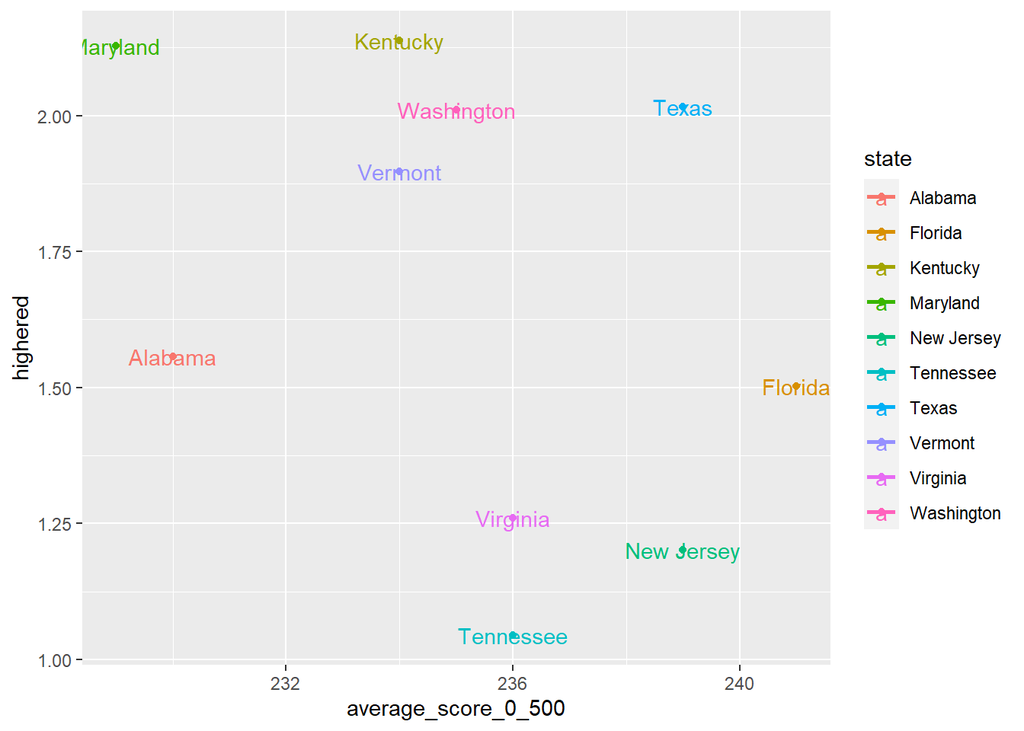

```r
joined_left %>%
  filter(state %in% c("Alabama", "Florida", "Kentucky", "Maryland", "New Jersey", "Tennessee", "Texas", "Vermont", "Virginia", "Washington")) %>%
  ggplot(aes(x = average_score_0_500, y = highered, color = state, group = state))+
  geom_point() +
  geom_smooth(method = "lm", se = FALSE) +
  geom_text(aes(label = state))
```

What interesting relationship (if any) did you find? Add a few notes below. Also, share ideas on what you could do to extend this analysis.

## Reach

This portion of the assignment is optional but offers you a chance to push your skills further.

We encourage you to change the theme, color, and other aesethetics of the plot. Do so by copying your code above and extending your graph. Also, consider visualizing a different variable’s relations with achievement.

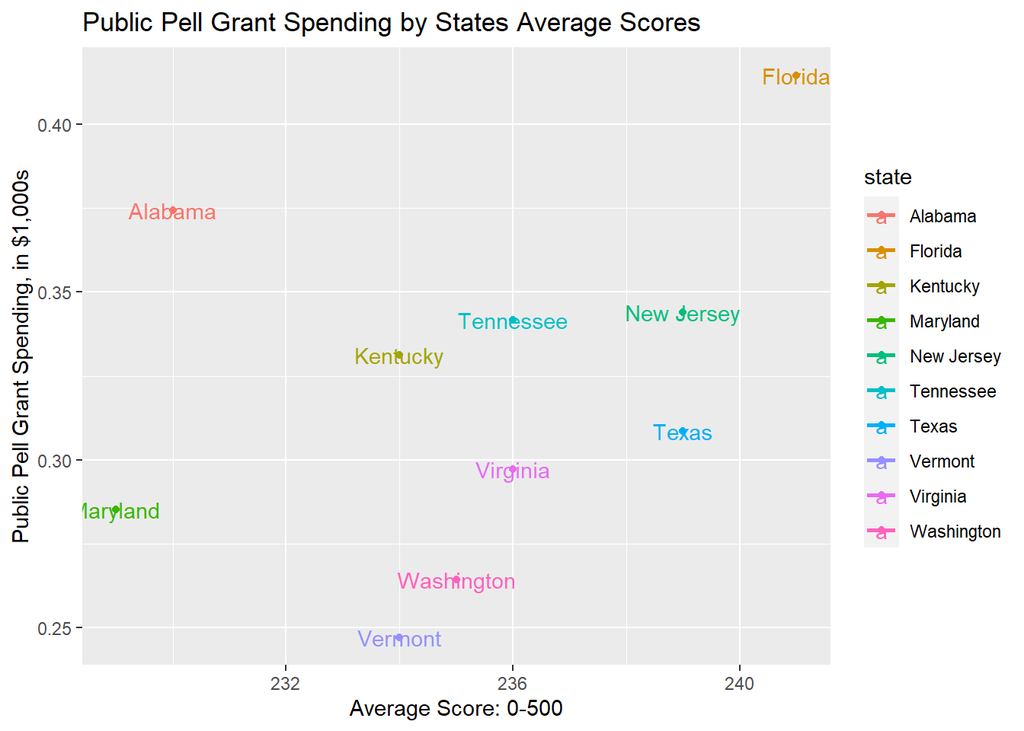

```r
joined_left %>%
  filter(state %in% c("Alabama", "Florida", "Kentucky", "Maryland", "New Jersey", "Tennessee", "Texas", "Vermont", "Virginia", "Washington")) %>%
  ggplot(aes(x = average_score_0_500, y = pell, color = state, group = state))+
  geom_point() +
  geom_smooth(method = "lm", se = FALSE) +
  geom_text(aes(label = state)) +
  xlab("Average Score: 0-500") +
  ylab("Public Pell Grant Spending, in $1,000s") +
  labs(title = "Public Pell Grant Spending by States Average Scores")
```

## Rubric

|  | Points Possible | Points Earned |
| --- | --- | --- |
| File knits | 2 |  |
| Code is accurately filled in for all 5 steps. | 10 |  |
| Step 3 Question | 3 |  |
| Step 4 Questions | 8 |  |
| Step 5 Questions | 7 |  |

## Knit and Submit

Complete the following steps to knit and publish your work (note - we’ll remove these steps after this week, as we know you’re becoming quite familiar with it!):

1. First, change the name of the `author:` in the [YAML header](https://bookdown.org/yihui/rmarkdown-cookbook/rmarkdown-anatomy.html#yaml-metadata) at the very top of this document to your name. The YAML header controls the style and feel for knitted document but doesn’t actually display in the final output.
2. Next, click the knit button in the toolbar above to “knit” your R Markdown document to a [HTML](https://bookdown.org/yihui/rmarkdown/html-document.html) file that will be saved in your R Project folder. You should see a formatted webpage appear in your Viewer tab in the lower right pan or in a new browser window. Let’s us know if you run into any issues with knitting.
3. Upload the HTML file that is now present in the same folder as this R Markdown file to Canvas to receive credit for this assignment!